# Di Zhen 1717719

dizhen

5/20/2020

Set working directory:

```r
setwd("D:/git/DPH112-xjtlu/week13")
```

Data

```r
ID <- c(1:129)
HIAA <- c(57,116,81,78,206,64,123,147,102,93,128,69,20,66,90,103,68,81,143,121,149,82,100,
          117,41,223,96,87,96,34,98,86,118,84,99,114,140,74,45,51,99,54,93,50,
          118,96,49,133,105,61,197,87,50,109,59,107,85,156,110,81,53,64,57,29,34,102,51,
          92,104,50,93,146,96,112,23,109,80,111,85,131,58,110,80,42,80,91,102,93,
          98,78,152,108,102,122,81,81,99,73,163,109,90,110,48,77,67,92,86,101,88,38,75,
          35,53,77,179,151,57,45,76,46,98,84,119,41,40,149,116,76,96)
TRYPT <- c(3315,2599,3334,2505,3269,3543,3374,2345,2855,2972,3904,2564,8832,4894,6017,3143,3729,3150,3955,4288,3404,2547,3633,
           3309,3315,3418,2295,3232,3496,2656,4318,3510,3613,3117,3496,4612,3051,3067,2782,5034,2564,4335,2596,2960,
           3916,2797,3699,2394,2495,2496,2123,3320,3117,3308,3280,3151,3955,3126,2913,3786,3616,3277,2656,4953,4340,3181,2513,
           2764,3098,2900,4125,6081,2972,3962,4894,3543,2622,3012,2685,3059,3946,3356,3671,4155,1923,3589,3839,2627,
           3181,4428,3303,5386,3282,2754,4321,3386,3344,3789,2131,3030,4731,4581,3292,4494,3453,3373,3787,3842,2882,2949,2248,
          3203,3248,3455,4521,3240,3905,3642,5233,4150,2579,3249,3381,4020,4569,3781,2346,3901,3822)
ONSET <- c(1,0,1,0,0,1,0,1,1,1,0,1,1,0,1,0,0,1,1,1,0,1,1,
           1,1,0,1,0,1,1,1,0,1,1,1,1,1,1,1,1,1,1,1,1,
           0,0,1,0,0,1,1,0,1,0,1,1,0,0,0,1,1,1,1,0,1,1,1,
           1,1,1,1,1,1,0,1,1,1,1,1,0,1,0,1,1,1,1,0,0,
           0,0,0,1,1,1,1,1,1,1,1,0,1,1,0,0,1,1,0,1,1,1,0,
           0,1,0,1,1,1,1,0,1,1,1,0,1,1,1,1,1,1)
mydata <- data.frame(ID,HIAA,TRYPT,as.factor(ONSET))
str(mydata)
```

```
## 'data.frame':    129 obs. of  4 variables:
##  $ ID              : int  1 2 3 4 5 6 7 8 9 10 ...
##  $ HIAA            : num  57 116 81 78 206 64 123 147 102 93 ...
##  $ TRYPT           : num  3315 2599 3334 2505 3269 ...
##  $ as.factor.ONSET.: Factor w/ 2 levels "0","1": 2 1 2 1 1 2 1 2 2 2 ...
```

```r
head(mydata)
```

```
##   ID HIAA TRYPT as.factor.ONSET.
## 1  1   57  3315                1
## 2  2  116  2599                0
## 3  3   81  3334                1
## 4  4   78  2505                0
## 5  5  206  3269                0
## 6  6   64  3543                1
```

## Question 1

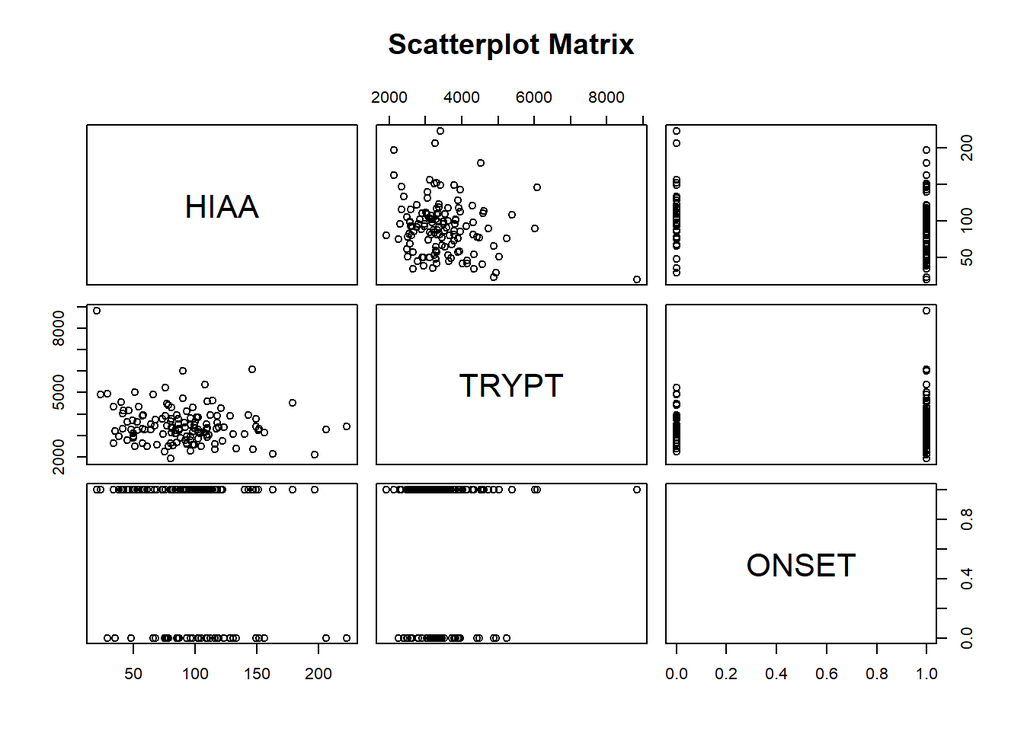

```r
pairs(~HIAA + TRYPT + ONSET, data = mydata,
      main = "Scatterplot Matrix")
```

## Question 2

```r
mydata.GLM <- glm(ONSET ~ HIAA + TRYPT,
                  data = mydata,
                  family = binomial(link = "logit"))
summary(mydata.GLM)
```

```
##
## Call:
## glm(formula = ONSET ~ HIAA + TRYPT, family = binomial(link = "logit"),
##     data = mydata)
##
## Deviance Residuals:
##     Min       1Q   Median       3Q      Max
## -1.9385  -1.3250   0.6931   0.8588   1.4165
##
## Coefficients:
##               Estimate Std. Error z value Pr(>|z|)
## (Intercept)  2.076e+00  1.049e+00   1.979   0.0478 *
## HIAA        -1.336e-02  5.512e-03  -2.425   0.0153 *
## TRYPT        5.055e-06  2.330e-04   0.022   0.9827
## ---
## Signif. codes:  0 '***' 0.001 '**' 0.01 '*' 0.05 '.' 0.1 ' ' 1
##
## (Dispersion parameter for binomial family taken to be 1)
##
##     Null deviance: 158.11  on 128  degrees of freedom
## Residual deviance: 151.66  on 126  degrees of freedom
## AIC: 157.66
##
## Number of Fisher Scoring iterations: 4
```

The logistic regression equation: $logit(ONSET) = 2.076 - 0.013 \times HIAA + 5.055*10^{-6} \times TRYPT$

## Question 3

```r
exp(mydata.GLM$coefficients)
```

```
## (Intercept)        HIAA       TRYPT
##   7.9695165   0.9867248   1.0000051
```

The odds ratio for HIAA is 0.987. ONSET = 0 (late onset of excessive alcohol consumption) is the reference category. For every increased unit of HIAA, the odds of a 1 (early) ONSET compared to a 0 (late) ONSET decreases by $(1-0.987) \times 100% = 1.3%$ after holding TRYPT constant.

The odds ratio for TRYPT is 1.000. For every increased unit of TRYPT, the odds of a 1 (early) ONSET compared to a 0 (late) ONSET increases very little (near to 0) after holding HIAA constant.

## Question 4

```r
exp(confint(mydata.GLM,level = 0.95))
```

```
##                2.5 %     97.5 %
## (Intercept) 1.017343 64.5294908
## HIAA        0.975614  0.9971573
## TRYPT       0.999567  1.0004900
```

[output not shown]

## Question 5

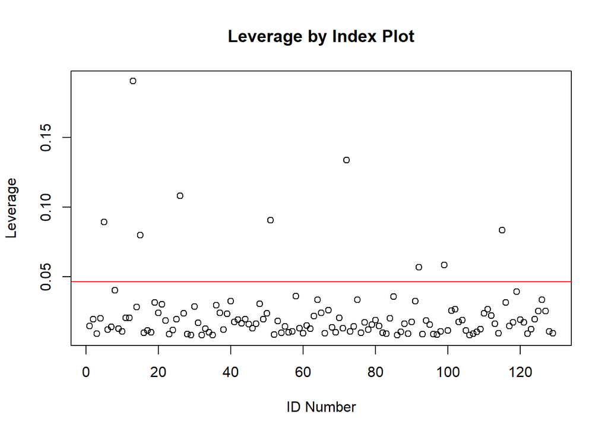

```r
mydata$HAT <- hatvalues(mydata.GLM)
HAT.CUT <- 2*(2+1)/length(ID)
plot(HAT ~ ID, data = mydata,
     ylab = "Leverage",
     xlab = "ID Number",
     main = "Leverage by Index Plot")
abline(h = HAT.CUT, col = "red")
```

```r
mydata[mydata$HAT > HAT.CUT,]
```

```
##      ID HIAA TRYPT as.factor.ONSET.        HAT
## 5     5  206  3269                0 0.08928632
## 13   13   20  8832                1 0.19036869
## 15   15   90  6017                1 0.07990276
## 26   26  223  3418                0 0.10822071
## 51   51  197  2123                1 0.09072977
## 72   72  146  6081                1 0.13365183
## 92   92  108  5386                1 0.05695178
## 99   99  163  2131                1 0.05854164
## 115 115  179  4521                1 0.08358640
```

The result shows that 9 observations are high-leverage points. They are outliers occuring in the independent variable space.

## Question 6

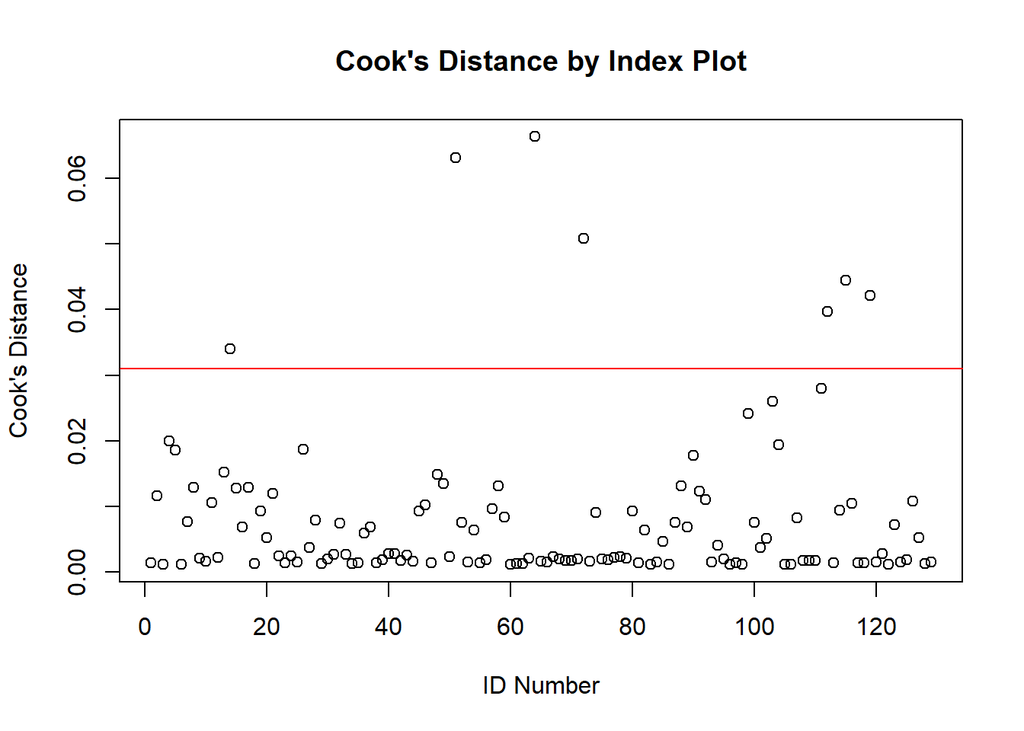

```r
mydata$COOK <- cooks.distance(mydata.GLM)
COOK.CUT <- 4/length(ID)
plot(COOK ~ ID, data = mydata,
     ylab = "Cook's Distance",
     xlab = "ID Number",
     main = "Cook's Distance by Index Plot")
abline(h = COOK.CUT, col = "red")
```

```r
mydata[mydata$COOK > COOK.CUT,]
```

```
##      ID HIAA TRYPT as.factor.ONSET.        HAT       COOK
## 14   14   66  4894                0 0.02851788 0.03405968
## 51   51  197  2123                1 0.09072977 0.06317323
## 64   64   29  4953                0 0.03352516 0.06635281
## 72   72  146  6081                1 0.13365183 0.05082376
## 112 112   35  3203                0 0.02240027 0.03964010
## 115 115  179  4521                1 0.08358640 0.04450261
## 119 119   76  5233                0 0.03933081 0.04210003
```

There are 7 observations with high Cook’s distance values. They are outliers.

## Question 7

```r
if(!require(LogisticDx)){install.packages("LogisticDx")}
```

```r
library("LogisticDx")
gof(mydata.GLM,plotROC = FALSE, g = 9)
```

```
##       chiSq  df     pVal
## PrI  128.14 126 0.430097
## drI  151.66 126 0.059468 .
## PrG  128.14 126 0.430097
## drG  151.66 126 0.059468 .
## PrCT 128.14 126 0.430097
## drCT 151.66 126 0.059468 .
## ---
## Signif. codes:  0 '***' 0.001 '**' 0.01 '*' 0.05 '.' 0.1 ' ' 1
##                      val df     pVal
## HL chiSq         7.29693  7 0.398632
## mHL F            0.88449  8 0.531782
## OsRo Z           1.64750 NA 0.099455 .
## SstPgeq0.5 Z     0.67431 NA 0.500113
## SstPl0.5 Z       0.36138 NA 0.717817
## SstBoth chiSq    0.58529  2 0.746287
## SllPgeq0.5 chiSq 0.45507  1 0.499938
## SllPl0.5 chiSq   0.13918  1 0.709100
## SllBoth chiSq    1.87458  2 0.391689
## ---
## Signif. codes:  0 '***' 0.001 '**' 0.01 '*' 0.05 '.' 0.1 ' ' 1
```

```r
if(!require(rms)){install.packages("rms")}
library("rms")
mydata.GLM.DX <- lrm(ONSET ~ HIAA + TRYPT)
mydata.GLM.DX
```

```
## Logistic Regression Model
##
##  lrm(formula = ONSET ~ HIAA + TRYPT)
##
##                       Model Likelihood     Discrimination    Rank Discrim.
##                          Ratio Test           Indexes           Indexes
##  Obs           129    LR chi2      6.45    R2       0.069    C       0.641
##   0             39    d.f.            2    g        0.541    Dxy     0.283
##   1             90    Pr(> chi2) 0.0397    gr       1.718    gamma   0.283
##  max |deriv| 5e-10                         gp       0.112    tau-a   0.120
##                                            Brier    0.201
##
##            Coef    S.E.   Wald Z Pr(>|Z|)
##  Intercept  2.0756 1.0487  1.98  0.0478
##  HIAA      -0.0134 0.0055 -2.42  0.0153
##  TRYPT      0.0000 0.0002  0.02  0.9827
##
```

The Nagelkirke’s $R^2$ is 0.069. The model explains about 6.9% of the variability in CDA classification.